# **Credit Card Fraud Detection**

dataset : https://www.kaggle.com/datasets/mlg-ulb/creditcardfraud

## **Introduction**

Credit card fraud represents a significant challenge for financial institutions worldwide, making the detection of fraudulent transactions crucial to protect both companies and customers. The purpose of this project is to build and evaluate several machine learning models capable of accurately classifying transactions as either normal or fraudulent.

We utilize a publicly available dataset consisting of credit card transactions made by European cardholders over a two-day period in September 2013. The dataset include **284,807 transactions**, out of which only **492 (~0.172%)** are fraudulent. This severe imbalance highlights a core challenge of this project.

Due to confidentiality requirements inherent in financial data, the majority of the dataset's columns (V1 to V28) have been anonymized via Principal Component Analysis (PCA), preserving user privacy while maintaining analytical usability. The only original (non-anonymized) features are:

- `Time`: indicating the elapsed time (in seconds) between each transaction and the first transaction recorded in the dataset.
- `Amount`: representing the amount of each transaction.

The target variable in this project is named `Class`, with:

- `0`: indicating a normal transaction
- `1`: indicating a fraudulent transaction

In this notebook, we will explore the dataset, implement multiple classification models, handle the class imbalance through resampling techniques, and finally, select and optimize the best-performing model based on its ability to reliably identify fraudulent transactions.

## **Summary**

- 1. Dataset Exploration
- 2. Data Preprocessing
- 3. Data Preparation (Train/Test/Validation Split)
- 4. Initial Model Evaluation
- 5. Handling Class Imbalance
- 6. Model Evaluation on Balanced Data
- 7. Hyperparameter Optimization
- 8. Conclusion

## **1. Dataset Exploration**

```python
# Importing Libraries
import pandas as pd
import numpy as np
import seaborn as sns
```

```python
dataset = pd.read_csv('creditcard.csv')
dataset.head()
```

|  | Time | V1 | V2 | V3 | V4 | V5 | V6 | V7 | V8 | V9 | ... | V21 | V22 | V23 | V24 | V25 | V26 | V27 | V28 | Amount | Class |
| --- | --- | --- | --- | --- | --- | --- | --- | --- | --- | --- | --- | --- | --- | --- | --- | --- | --- | --- | --- | --- | --- |
| 0 | 0.0 | -1.359807 | -0.072781 | 2.536347 | 1.378155 | -0.338321 | 0.462388 | 0.239599 | 0.098698 | 0.363787 | ... | -0.018307 | 0.277838 | -0.110474 | 0.066928 | 0.128539 | -0.189115 | 0.133558 | -0.021053 | 149.62 | 0 |
| 1 | 0.0 | 1.191857 | 0.266151 | 0.166480 | 0.448154 | 0.060018 | -0.082361 | -0.078803 | 0.085102 | -0.255425 | ... | -0.225775 | -0.638672 | 0.101288 | -0.339846 | 0.167170 | 0.125895 | -0.008983 | 0.014724 | 2.69 | 0 |
| 2 | 1.0 | -1.358354 | -1.340163 | 1.773209 | 0.379780 | -0.503198 | 1.800499 | 0.791461 | 0.247676 | -1.514654 | ... | 0.247998 | 0.771679 | 0.909412 | -0.689281 | -0.327642 | -0.139097 | -0.055353 | -0.059752 | 378.66 | 0 |
| 3 | 1.0 | -0.966272 | -0.185226 | 1.792993 | -0.863291 | -0.010309 | 1.247203 | 0.237609 | 0.377436 | -1.387024 | ... | -0.108300 | 0.005274 | -0.190321 | -1.175575 | 0.647376 | -0.221929 | 0.062723 | 0.061458 | 123.50 | 0 |
| 4 | 2.0 | -1.158233 | 0.877737 | 1.548718 | 0.403034 | -0.407193 | 0.095921 | 0.592941 | -0.270533 | 0.817739 | ... | -0.009431 | 0.798278 | -0.137458 | 0.141267 | -0.206010 | 0.502292 | 0.219422 | 0.215153 | 69.99 | 0 |

5 rows × 31 columns

```python
dataset.describe()
```

|  | Time | V1 | V2 | V3 | V4 | V5 | V6 | V7 | V8 | V9 | ... | V21 | V22 | V23 | V24 | V25 | V26 | V27 | V28 | Amount | Class |
| --- | --- | --- | --- | --- | --- | --- | --- | --- | --- | --- | --- | --- | --- | --- | --- | --- | --- | --- | --- | --- | --- |
| count | 284807.000000 | 2.848070e+05 | 2.848070e+05 | 2.848070e+05 | 2.848070e+05 | 2.848070e+05 | 2.848070e+05 | 2.848070e+05 | 2.848070e+05 | 2.848070e+05 | ... | 2.848070e+05 | 2.848070e+05 | 2.848070e+05 | 2.848070e+05 | 2.848070e+05 | 2.848070e+05 | 2.848070e+05 | 2.848070e+05 | 284807.000000 | 284807.000000 |
| mean | 94813.859575 | 1.168375e-15 | 3.416908e-16 | -1.379537e-15 | 2.074095e-15 | 9.604066e-16 | 1.487313e-15 | -5.556467e-16 | 1.213481e-16 | -2.406331e-15 | ... | 1.654067e-16 | -3.568593e-16 | 2.578648e-16 | 4.473266e-15 | 5.340915e-16 | 1.683437e-15 | -3.660091e-16 | -1.227390e-16 | 88.349619 | 0.001727 |
| std | 47488.145955 | 1.958696e+00 | 1.651309e+00 | 1.516255e+00 | 1.415869e+00 | 1.380247e+00 | 1.332271e+00 | 1.237094e+00 | 1.194353e+00 | 1.098632e+00 | ... | 7.345240e-01 | 7.257016e-01 | 6.244603e-01 | 6.056471e-01 | 5.212781e-01 | 4.822270e-01 | 4.036325e-01 | 3.300833e-01 | 250.120109 | 0.041527 |
| min | 0.000000 | -5.640751e+01 | -7.271573e+01 | -4.832559e+01 | -5.683171e+00 | -1.137433e+02 | -2.616051e+01 | -4.355724e+01 | -7.321672e+01 | -1.343407e+01 | ... | -3.483038e+01 | -1.093314e+01 | -4.480774e+01 | -2.836627e+00 | -1.029540e+01 | -2.604551e+00 | -2.256568e+01 | -1.543008e+01 | 0.000000 | 0.000000 |
| 25% | 54201.500000 | -9.203734e-01 | -5.985499e-01 | -8.903648e-01 | -8.486401e-01 | -6.915971e-01 | -7.682956e-01 | -5.540759e-01 | -2.086297e-01 | -6.430976e-01 | ... | -2.283949e-01 | -5.423504e-01 | -1.618463e-01 | -3.545861e-01 | -3.171451e-01 | -3.269839e-01 | -7.083953e-02 | -5.295979e-02 | 5.600000 | 0.000000 |
| 50% | 84692.000000 | 1.810880e-02 | 6.548556e-02 | 1.798463e-01 | -1.984653e-02 | -5.433583e-02 | -2.741871e-01 | 4.010308e-02 | 2.235804e-02 | -5.142873e-02 | ... | -2.945017e-02 | 6.781943e-03 | -1.119293e-02 | 4.097606e-02 | 1.659350e-02 | -5.213911e-02 | 1.342146e-03 | 1.124383e-02 | 22.000000 | 0.000000 |
| 75% | 139320.500000 | 1.315642e+00 | 8.037239e-01 | 1.027196e+00 | 7.433413e-01 | 6.119264e-01 | 3.985649e-01 | 5.704361e-01 | 3.273459e-01 | 5.971390e-01 | ... | 1.863772e-01 | 5.285536e-01 | 1.476421e-01 | 4.395266e-01 | 3.507156e-01 | 2.409522e-01 | 9.104512e-02 | 7.827995e-02 | 77.165000 | 0.000000 |
| max | 172792.000000 | 2.454930e+00 | 2.205773e+01 | 9.382558e+00 | 1.687534e+01 | 3.480167e+01 | 7.330163e+01 | 1.205895e+02 | 2.000721e+01 | 1.559499e+01 | ... | 2.720284e+01 | 1.050309e+01 | 2.252841e+01 | 4.584549e+00 | 7.519589e+00 | 3.517346e+00 | 3.161220e+01 | 3.384781e+01 | 25691.160000 | 1.000000 |

8 rows × 31 columns

```python
# Check if there are any missing values.
print(dataset.isna().sum())
print(dataset.info())
```

```
Time      0
V1        0
V2        0
V3        0
V4        0
V5        0
V6        0
V7        0
V8        0
V9        0
V10       0
V11       0
V12       0
V13       0
V14       0
V15       0
V16       0
V17       0
V18       0
V19       0
V20       0
V21       0
V22       0
V23       0
V24       0
V25       0
V26       0
V27       0
V28       0
Amount    0
Class     0
dtype: int64
<class 'pandas.core.frame.DataFrame'>
RangeIndex: 284807 entries, 0 to 284806
Data columns (total 31 columns):
 #   Column  Non-Null Count   Dtype
---  ------  --------------   -----
 0   Time    284807 non-null  float64
 1   V1      284807 non-null  float64
 2   V2      284807 non-null  float64
```

[output cut: 16 more lines]

```
 19  V19     284807 non-null  float64
 20  V20     284807 non-null  float64
 21  V21     284807 non-null  float64
 22  V22     284807 non-null  float64
 23  V23     284807 non-null  float64
 24  V24     284807 non-null  float64
 25  V25     284807 non-null  float64
 26  V26     284807 non-null  float64
 27  V27     284807 non-null  float64
 28  V28     284807 non-null  float64
 29  Amount  284807 non-null  float64
 30  Class   284807 non-null  int64
dtypes: float64(30), int64(1)
memory usage: 67.4 MB
None
```

```python
# Let's examine the class distribution to assess the level of imbalance in the dataset.
print(dataset.value_counts(["Class"]))

pourcentage = (dataset['Class'] == 1).sum() / len(dataset) * 100
print(f'{pourcentage:.3f} % of the transaction are fraudulent')
```

```
Class
0        284315
1           492
Name: count, dtype: int64
0.173 % of the transaction are fraudulent
```

[output not shown]

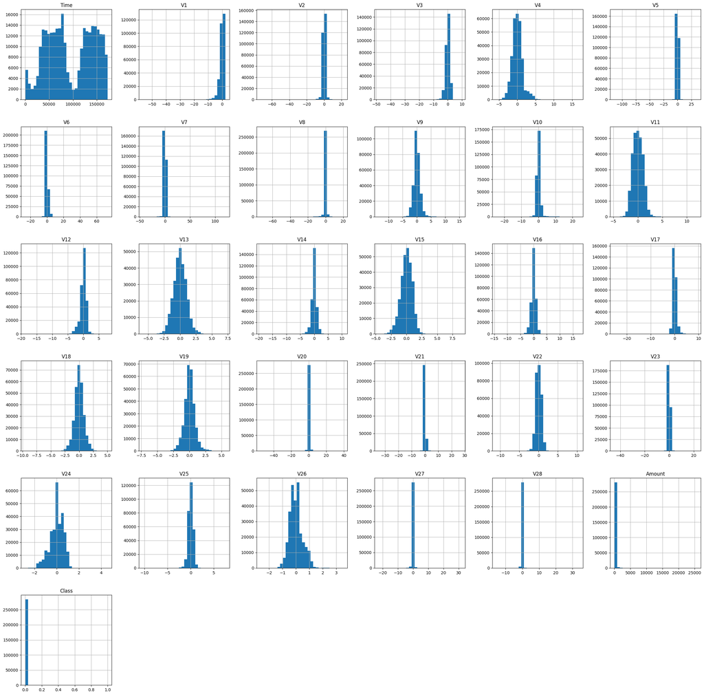

```python
# Plotting histograms for all features in the dataset to visualize their distributions
dataset.hist(bins=30, figsize=(30,30))
```

## **2. Data Preprocessing**

In this section, we will preprocess our data to improve model performance. Specifically, we will scale features `Amount` and `Time` to eliminate extreme values and normalize their range, making the data easier to process for our models.

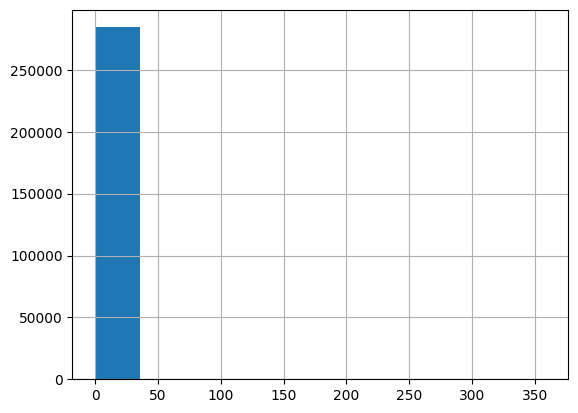

```python
# Using RobustScaler to reduce the impact of outliers in the 'Amount' feature
from sklearn.preprocessing import RobustScaler

new_dataset = dataset.copy()
new_dataset['Amount'] = RobustScaler().fit_transform(new_dataset['Amount'].to_numpy().reshape(-1, 1))

new_dataset['Amount'].hist()
```

```python
# Checking descriptive statistics to verify the reduction of extreme values
new_dataset['Amount'].describe()

# Previously, we had extreme transaction values (e.g., 25,000). After scaling, we can see the maximum is significantly reduced.
```

```
count    284807.000000
mean          0.927124
std           3.495006
min          -0.307413
25%          -0.229162
50%           0.000000
75%           0.770838
max         358.683155
Name: Amount, dtype: float64
```

```python
# Normalizing 'Time' feature to a [0, 1] range for better readability and performance
time = new_dataset['Time']
new_dataset['Time'] = (time - time.min()) / (time.max() - time.min())

# Verifying the normalization
new_dataset['Time'].describe()
```

```
count    284807.000000
mean          0.548717
std           0.274828
min           0.000000
25%           0.313681
50%           0.490138
75%           0.806290
max           1.000000
Name: Time, dtype: float64
```

## **3. Data Preparation (Train/Test/Validation Split)**

In this section, we split our dataset into three separate subsets:

- **Training set**: to train our models
- **Test set**: to evaluate general performance after training
- **Validation set**: to tune hyperparameters and verify the generalization of the models

After splitting, we convert these subsets into numpy arrays and separate each subset into input features (`x`) and target labels (`y`) for easier manipulation in subsequent steps.

```python
# Splitting dataset into train, test, and validation sets based on index positions
train, test, val = new_dataset[:240000], new_dataset[240000:262000], new_dataset[262000:]

# Checking the distribution of the target variable ('Class') across each subset
train['Class'].value_counts(), test['Class'].value_counts(), val['Class'].value_counts()
```

```
(Class
 0    239563
 1       437
 Name: count, dtype: int64,
 Class
 0    21963
 1       37
 Name: count, dtype: int64,
 Class
 0    22789
 1       18
 Name: count, dtype: int64)
```

```python
# Converting data subsets to numpy arrays for easier processing in machine learning models
train_np, test_np, val_np = train.to_numpy(), test.to_numpy(), val.to_numpy()

# Checking the shape of the arrays (rows, columns)
train_np.shape, test_np.shape, val_np.shape
```

```
((240000, 31), (22000, 31), (22807, 31))
```

```python
# Splitting each subset into input features (x) and target labels (y)
x_train, y_train = train_np[:, :-1], train_np[:,-1]
x_test, y_test = test_np[:, :-1], test_np[:,-1]
x_val, y_val = val_np[:, :-1], val_np[:,-1]

# Checking the shapes of features and labels arrays
x_train.shape, y_train.shape, x_test.shape, y_test.shape, x_val.shape, y_val.shape
```

```
((240000, 30), (240000,), (22000, 30), (22000,), (22807, 30), (22807,))
```

## **4. Initial Model Evaluation**

In this section, we evaluate different machine learning models to identify fraudulent transactions. Each model is trained on the training set and evaluated on the validation set using classification metrics.

- Logistic Regression
- Random Forest
- Gradient Boosting
- Linear SVC

### **Logistic Regression**

**Logistic Regression** is a straightforward statistical model used for binary classification tasks. It estimates the probability that an input belongs to a particular class by fitting data to a logistic function, defining a clear linear decision boundary between classes.

Due to its simplicity and interpretability, Logistic Regression serves as an excellent baseline model for initial evaluation.

```python
from sklearn.linear_model import LogisticRegression

# Training Logistic Regression model
logistic_model = LogisticRegression()
logistic_model.fit(x_train, y_train)

# Evaluating accuracy on the test set
accuracy = logistic_model.score(x_test, y_test)
print("Accuracy:", accuracy)
```

```
Accuracy: 0.9991818181818182
```

```python
# Classification report with precision, recall, f1-score for each class
from sklearn.metrics import classification_report

report1 = classification_report(y_val, logistic_model.predict(x_val), target_names=['Not Fraud', 'Fraud'])
print(report1)
```

```
              precision    recall  f1-score   support

   Not Fraud       1.00      1.00      1.00     22789
       Fraud       0.83      0.28      0.42        18

    accuracy                           1.00     22807
   macro avg       0.92      0.64      0.71     22807
weighted avg       1.00      1.00      1.00     22807
```

**Detailed Interpretation:**

Precision:

- `Not Fraud`: 1.00 means every transaction classified as legitimate was indeed legitimate (no false positives).
- `Fraud` : 0.83 means approximately 83% of transactions classified as fraudulent were actually fraud. However, around 17% of predicted frauds were false alarms.

Recall (Sensitivity):

- `Not Fraud`: 1.00 indicates the model correctly identified almost every legitimate transaction.
- `Fraud`: 0.28 is very low, meaning the model detected only 28% of actual fraudulent transactions and missed 72% of them.

F1-score:

- `Fraud`: 0.42, which is relatively low, reflecting the model’s overall limited capability to effectively detect fraudulent transactions due to the low recall.

Support:

- Clearly highlights the imbalance issue: 22,789 legitimate transactions vs only 18 frauds.

Accuracy:

- 1.00 appears excellent, but it's misleading here due to the severe class imbalance.

Macro Average:

- 0.64 in recall indicates poor overall detection of fraud.

Weighted Average:

- High due to the dominance of legitimate transactions.

**Conclusion:** This Logistic Regression model is highly precise for normal transactions but inadequate for fraud detection because it fails to identify a significant portion of actual fraud cases.

### **Random Forest**

**Random Forest** combines multiple decision trees built from randomly selected subsets of the data. Each tree votes to classify an input, improving predictive performance and robustness against overfitting. It’s particularly effective at capturing complex, nonlinear relationships in data, which might better reveal subtle fraud patterns.

```python
from sklearn.ensemble import RandomForestClassifier

# Training Random Forest classifier
rf = RandomForestClassifier(max_depth=2, n_jobs=-1)
# max_depth: specifies the maximum depth of each decision tree; here, we are setting it to 2, limiting complexity to avoid overfitting
# n_jobs: specifies the number of processes used for model training; here, all available processors are utilized
rf.fit(x_train, y_train)

# Classification performance report
result2 = classification_report(y_val, rf.predict(x_val), target_names=['Not Fraud', 'Fraud'])
print(result2)
```

```
              precision    recall  f1-score   support

   Not Fraud       1.00      1.00      1.00     22789
       Fraud       0.89      0.44      0.59        18

    accuracy                           1.00     22807
   macro avg       0.94      0.72      0.80     22807
weighted avg       1.00      1.00      1.00     22807
```

**Interpretation :**

The Random Forest significantly improves fraud detection compared to Logistic Regression. Precision increased (0.89 vs 0.83), meaning fewer false positives when predicting fraud. Recall improved notably (0.44 vs 0.28), catching more actual fraud cases. Overall, it achieves a better balance (higher F1-score).

**Conclusion:** Random Forest performs better but still misses many fraud cases due to class imbalance.

### **Gradient Boosting**

**Gradient Boosting** builds decision trees sequentially, each aiming to correct the errors of the previous one. This iterative improvement process typically yields strong predictive performance, making it ideal for complex tasks like fraud detection where subtle patterns exist.

```python
from sklearn.ensemble import GradientBoostingClassifier

# Training Gradient Boosting Classifier
gbc = GradientBoostingClassifier(n_estimators=50, learning_rate=1.0, max_depth=1, random_state=0)
# n_estimators: number of decision trees; a moderate value (50) for faster training while maintaining accuracy
# learning_rate: controls contribution of each tree; higher value (1.0) chosen for rapid convergence (though lower values usually provide smoother results)
# max_depth: maximum depth of each tree; shallow trees (depth=1) to prevent overfitting
# random_state: ensures reproducibility of results

gbc.fit(x_train, y_train)

# Classification performance report
result3 = classification_report(y_val, gbc.predict(x_val), target_names=['Not Fraud', 'Fraud'])
print(result3)
```

```
              precision    recall  f1-score   support

   Not Fraud       1.00      1.00      1.00     22789
       Fraud       0.71      0.56      0.62        18

    accuracy                           1.00     22807
   macro avg       0.86      0.78      0.81     22807
weighted avg       1.00      1.00      1.00     22807
```

**Interpretation:**

Gradient Boosting achieves a notably higher recall (0.56), meaning it identifies more fraud cases compared to previous models. However, its precision dropped (0.71), indicating more false positives. The higher F1-score (0.62) indicates an overall better balance between detecting fraud and avoiding false alerts.

**Conclusion:** This model detects fraud more effectively at the expense of slightly more false positives.

### **Linear SVC**

**LinearSVC (Linear Support Vector Classifier)** identifies the optimal hyperplane separating classes with the maximum possible margin, effectively handling large and high-dimensional datasets. Given the PCA-anonymized features of our dataset, LinearSVC could provide robust and reliable performance.

```python
from sklearn.svm import LinearSVC

# Training Linear Support Vector Classifier
svc = LinearSVC()
# No parameters specified explicitly: default parameters are sufficient for initial evaluation, providing a simple baseline performance measure

svc.fit(x_train, y_train)

# Classification performance report
result4 = classification_report(y_val, svc.predict(x_val), target_names=['Not Fraud', 'Fraud'])
print(result4)
```

```
              precision    recall  f1-score   support

   Not Fraud       1.00      1.00      1.00     22789
       Fraud       1.00      0.44      0.62        18

    accuracy                           1.00     22807
   macro avg       1.00      0.72      0.81     22807
weighted avg       1.00      1.00      1.00     22807
```

**Interpretation:**

LinearSVC shows perfect precision (1.00), meaning every predicted fraud is truly fraudulent (no false positives). However, recall is moderate (0.44), indicating many fraud cases remain undetected. Overall, LinearSVC has excellent reliability when it identifies fraud, but still leaves room for improvement in detecting more fraud cases.

**Conclusion:** LinearSVC is highly accurate when identifying fraud, though its moderate recall indicates a need to improve its sensitivity to actual fraud cases.

After evaluating multiple classification models, we observed that while models like **Random Forest, Gradient Boosting, and especially LinearSVC** performed better than **Logistic Regression**, they still struggled to effectively detect all fraud cases, mainly due to the severe imbalance in the dataset. This class imbalance significantly limits the recall for fraudulent transactions, causing many real fraud cases to remain undetected.

## **5. Handling Class Imbalance**

In this section, we will reduce the class imbalance observed in the original dataset to improve our models' fraud detection performance. To achieve this, we'll create a balanced dataset containing equal amounts of fraudulent and non-fraudulent transactions, shuffle the data for randomness, and then split it again into training, testing, and validation subsets.

```python
# Separating transactions by class
not_frauds = new_dataset.query('Class == 0')  # Filter for legitimate transactions
frauds = new_dataset.query('Class == 1')      # Filter for fraudulent transactions

# Displaying counts of each class
not_frauds['Class'].value_counts(), frauds['Class'].value_counts()
```

```
(Class
 0    284315
 Name: count, dtype: int64,
 Class
 1    492
 Name: count, dtype: int64)
```

```python
# Creating a balanced dataset with an equal number of fraud and non-fraud cases
balanced_dataset = pd.concat([frauds, not_frauds.sample(len(frauds), random_state=1)])

# Verifying the class distribution
balanced_dataset['Class'].value_counts()
```

```
Class
1    492
0    492
Name: count, dtype: int64
```

```python
# Shuffling the dataset rows to ensure randomness
balanced_dataset = balanced_dataset.sample(frac=1, random_state=1)
balanced_dataset
```

|  | Time | V1 | V2 | V3 | V4 | V5 | V6 | V7 | V8 | V9 | ... | V21 | V22 | V23 | V24 | V25 | V26 | V27 | V28 | Amount | Class |
| --- | --- | --- | --- | --- | --- | --- | --- | --- | --- | --- | --- | --- | --- | --- | --- | --- | --- | --- | --- | --- | --- |
| 189959 | 0.744404 | -0.865285 | -0.979506 | 2.587540 | -2.781144 | -0.887336 | -0.579689 | -0.976755 | 0.132058 | -1.658263 | ... | -0.106978 | -0.010528 | -0.211955 | 0.021026 | 0.358237 | -0.209483 | 0.062051 | 0.074730 | -0.195626 | 0 |
| 107637 | 0.408213 | -2.271755 | -0.457655 | -2.589055 | 2.230778 | -4.278983 | 0.388610 | 0.102485 | 0.813128 | -1.092921 | ... | 1.096342 | 0.658399 | 1.711676 | 0.333540 | 0.538591 | -0.193529 | 0.258194 | 0.247269 | 11.218193 | 1 |
| 275992 | 0.965502 | -2.027135 | -1.131890 | -1.135194 | 1.086963 | -0.010547 | 0.423797 | 3.790880 | -1.155595 | -0.063434 | ... | -0.315105 | 0.575520 | 0.490842 | 0.756502 | -0.142685 | -0.602777 | 0.508712 | -0.091646 | 8.555858 | 1 |
| 120862 | 0.439760 | 0.531678 | -1.108844 | 0.276972 | 0.386453 | -1.038906 | -0.810526 | 0.395582 | -0.322635 | 0.068460 | ... | 0.000589 | -0.824566 | -0.174821 | 0.479535 | -0.094335 | 0.698329 | -0.130716 | 0.083227 | 5.094669 | 0 |
| 207960 | 0.792328 | 1.878626 | 0.162765 | -0.167433 | 3.465196 | 0.197332 | 1.157212 | -0.676783 | 0.473890 | -0.386278 | ... | -0.217428 | -0.785738 | 0.406279 | -0.056071 | -0.560484 | -0.388620 | -0.012717 | -0.038421 | -0.223713 | 0 |
| ... | ... | ... | ... | ... | ... | ... | ... | ... | ... | ... | ... | ... | ... | ... | ... | ... | ... | ... | ... | ... | ... |
| 236229 | 0.860700 | -1.319844 | 0.290232 | -0.223288 | -0.351133 | 2.003048 | 0.004449 | 2.111141 | -0.155835 | -1.277863 | ... | 0.259482 | 0.301030 | -0.388021 | -1.449786 | 1.720770 | -0.282374 | -0.106111 | 0.026727 | 2.379375 | 0 |
| 15810 | 0.157716 | -25.942434 | 14.601998 | -27.368650 | 6.378395 | -19.104033 | -4.684806 | -18.261393 | 17.052566 | -3.742605 | ... | 1.784316 | -1.917759 | -1.235787 | 0.161105 | 1.820378 | -0.219359 | 1.388786 | 0.406810 | 1.089779 | 1 |
| 1569 | 0.007107 | -0.693097 | 0.720897 | 0.487926 | 1.545283 | -0.123343 | 0.151906 | 1.821822 | -0.176592 | -1.514396 | ... | 0.200782 | 0.193611 | 0.288196 | -0.081502 | 0.281742 | -0.136080 | 0.050083 | 0.147487 | 3.604136 | 0 |
| 107067 | 0.406674 | -1.512516 | 1.133139 | -1.601052 | 2.813401 | -2.664503 | -0.310371 | -1.520895 | 0.852996 | -1.496495 | ... | 0.729828 | 0.485286 | 0.567005 | 0.323586 | 0.040871 | 0.825814 | 0.414482 | 0.267265 | 4.137637 | 1 |
| 9509 | 0.081902 | -4.710529 | 8.636214 | -15.496222 | 10.313349 | -4.351341 | -3.322689 | -10.788373 | 5.060381 | -5.689311 | ... | 1.990545 | 0.223785 | 0.554408 | -1.204042 | -0.450685 | 0.641836 | 1.605958 | 0.721644 | -0.293440 | 1 |

984 rows × 31 columns

```python
# Converting balanced dataset to NumPy arrays and splitting into subsets
balanced_dataset_np = balanced_dataset.to_numpy()

# Splitting into training (700 samples), testing (142 samples), and validation (remaining samples)
x_train_b, y_train_b = balanced_dataset_np[:700, :-1], balanced_dataset_np[:700, -1].astype(int)
x_test_b, y_test_b = balanced_dataset_np[700:842, :-1], balanced_dataset_np[700:842, -1].astype(int)
x_val_b, y_val_b = balanced_dataset_np[842:, :-1], balanced_dataset_np[842:, -1].astype(int)

# Checking shapes of each dataset subset
x_train_b.shape, y_train_b.shape, x_test_b.shape, y_test_b.shape, x_val_b.shape, y_val_b.shape
```

```
((700, 30), (700,), (142, 30), (142,), (142, 30), (142,))
```

```python
# Verifying balanced class distribution across subsets
pd.Series(y_train_b).value_counts(), pd.Series(y_test_b).value_counts(), pd.Series(y_val_b).value_counts()
```

```
(1    353
 0    347
 Name: count, dtype: int64,
 0    73
 1    69
 Name: count, dtype: int64,
 0    72
 1    70
 Name: count, dtype: int64)
```

## **6. Model Evaluation on Balanced Data**

In this section, we re-evaluate our previously tested models using the newly balanced dataset to determine whether balancing the data significantly improves fraud detection performance.

```python
### Logistic Regression
logistic_model_b = LogisticRegression()
logistic_model_b.fit(x_train_b, y_train_b)
logistic_model_b.score(x_test_b, y_test_b)
report1_b = classification_report(y_val_b, logistic_model_b.predict(x_val_b), target_names=['Not Fraud', 'Fraud'])

### Random Forest Classifier
rf_b = RandomForestClassifier(max_depth=2, n_jobs=-1)
rf_b.fit(x_train_b, y_train_b)
rf_b.score(x_test_b, y_test_b)
report2_b = classification_report(y_val_b, rf_b.predict(x_val_b), target_names=['Not Fraud', 'Fraud'])

### Gradient Boosting Classifier
gbc_b = GradientBoostingClassifier(n_estimators=50, learning_rate=1.0, max_depth=1, random_state=0)
gbc_b.fit(x_train_b, y_train_b)
gbc_b.score(x_test_b, y_test_b)
report3_b = classification_report(y_val_b, gbc_b.predict(x_val_b), target_names=['Not Fraud', 'Fraud'])

### Linear SVC
svc_b = LinearSVC()
svc_b.fit(x_train_b, y_train_b)
svc_b.score(x_test_b, y_test_b)
report4_b = classification_report(y_val_b, svc_b.predict(x_val_b), target_names=['Not Fraud', 'Fraud'])

print("\n===============================================")
print("=== Logistic Regression ===")
print("===============================================")
print(report1_b)
print("\n===============================================")
print("=== Random Forest ===")
print("===============================================")
print(report2_b)
print("\n===============================================")
print("=== Gradient Boosting ===")
print("===============================================")
print(report3_b)
print("\n===============================================")
print("=== Linear SVC ===")
print("===============================================")
print(report4_b)
```

```
===============================================
=== Logistic Regression ===
===============================================
              precision    recall  f1-score   support

   Not Fraud       0.92      1.00      0.96        72
       Fraud       1.00      0.91      0.96        70

    accuracy                           0.96       142
   macro avg       0.96      0.96      0.96       142
weighted avg       0.96      0.96      0.96       142


===============================================
=== Random Forest ===
===============================================
              precision    recall  f1-score   support

   Not Fraud       0.89      1.00      0.94        72
       Fraud       1.00      0.87      0.93        70

    accuracy                           0.94       142
   macro avg       0.94      0.94      0.94       142
weighted avg       0.94      0.94      0.94       142


===============================================
=== Gradient Boosting ===
===============================================
              precision    recall  f1-score   support

   Not Fraud       0.93      0.94      0.94        72
       Fraud       0.94      0.93      0.94        70

    accuracy                           0.94       142
   macro avg       0.94      0.94      0.94       142
weighted avg       0.94      0.94      0.94       142


===============================================
=== Linear SVC ===
===============================================
              precision    recall  f1-score   support

   Not Fraud       0.93      0.99      0.96        72
       Fraud       0.98      0.93      0.96        70

    accuracy                           0.96       142
   macro avg       0.96      0.96      0.96       142
weighted avg       0.96      0.96      0.96       142
```

**Results interpretation after balancing:**

These results confirm that addressing class imbalance significantly enhances fraud detection performance, particularly for Logistic Regression and LinearSVC.

To accurately distinguish between these models, we will now use the **Area Under the Precision-Recall Curve (AUPRC)**, a metric providing a comprehensive evaluation by considering the overall trade-off between precision (avoiding false positives) and recall (detecting true frauds), making it especially relevant for evaluating model performance on balanced yet sensitive datasets.

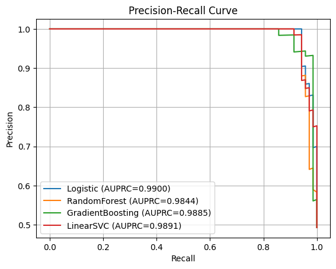

```python
from sklearn.metrics import precision_recall_curve, average_precision_score
import matplotlib.pyplot as plt

models = {'Logistic': logistic_model_b,
          'RandomForest': rf_b,
          'GradientBoosting': gbc_b,
          'LinearSVC': svc_b
          }

# Compute and plot Precision-Recall curves for each model
for name, model in models.items():

    # Use predict_proba or decision_function depending on the model
    if hasattr(model, "predict_proba"):
        scores = model.predict_proba(x_val_b)[:, 1]  # Probability of class "Fraud"
    else:
        scores = model.decision_function(x_val_b)    # Decision function score for LinearSVC

    precision, recall, _ = precision_recall_curve(y_val_b, scores)
    auprc = average_precision_score(y_val_b, scores)

    plt.plot(recall, precision, label=f"{name} (AUPRC={auprc:.4f})")

plt.xlabel('Recall')
plt.ylabel('Precision')
plt.title('Precision-Recall Curve')
plt.legend()
plt.grid()
```

**Interpretation:**

Based on the final Precision-Recall curve (AUPRC), the **Logistic Regression model seems to be the best-performing model with an AUPRC score of 0.9900**.

## **7. Hyperparameter Optimization**

In this final step, we optimize the hyperparameters of our best-performing model (Logistic Regression) to further enhance its performance and generalization. To achieve this, we employ GridSearchCV, systematically testing multiple parameter combinations using cross-validation to identify the optimal configuration.

```python
from sklearn.model_selection import GridSearchCV
from sklearn.linear_model import LogisticRegression

# Defining the hyperparameter grid for Logistic Regression
param_grid = {
    'C': [0.01, 0.1, 1, 10, 100],                # Regularization strength
    'penalty': ['l1', 'l2'],                     # Regularization penalty type
    'solver': ['liblinear'],                     # Optimization algorithm compatible with l1/l2 penalty
    'class_weight': [None, 'balanced']           # Class imbalance handling
}

# Setting up GridSearchCV with cross-validation
grid_search = GridSearchCV(
    LogisticRegression(random_state=42),
    param_grid,
    scoring='average_precision',  # Optimizing based on AUPRC
    cv=5,                         # 5-fold cross-validation
    n_jobs=-1,                    # Utilize all available CPU cores
    verbose=2                     # Show detailed training output
)

# Fitting GridSearchCV on the balanced training dataset
grid_search.fit(x_train_b, y_train_b)

# Displaying the best hyperparameters and corresponding AUPRC score
print("Best hyperparameters found:", grid_search.best_params_)
print(f"Best AUPRC score achieved: {grid_search.best_score_:.4f}")
```

```
Fitting 5 folds for each of 20 candidates, totalling 100 fits
Best hyperparameters found: {'C': 1, 'class_weight': 'balanced', 'penalty': 'l1', 'solver': 'liblinear'}
Best AUPRC score achieved: 0.9834
```

**Interpretation:**

After performing hyperparameter optimization on the Logistic Regression model using GridSearchCV, we obtained a final optimized AUPRC score of 0.9834, slightly lower than our initial score of 0.9900.

This minor decrease is expected and normal: hyperparameter optimization via cross-validation aims to maximize the model’s generalizability and robustness across multiple subsets of data rather than optimizing solely for a single validation set. Therefore, the optimized Logistic Regression model is generally more robust, reliable, and suitable for predicting unseen data in real-world applications.

## **8. Conclusion**

This classification project on credit card fraud detection allowed us to explore various machine learning approaches and highlighted the critical importance of data preprocessing, especially addressing class imbalance. Among the models tested, Logistic Regression demonstrated superior performance after rebalancing the dataset, offering an excellent balance between raw predictive performance and generalizability.

In practical terms, these results can be leveraged effectively in real-world scenarios to detect fraud reliably while minimizing costly errors. For future improvements, exploring more advanced resampling methods or employing other sophisticated machine learning techniques could further enhance fraud detection accuracy and robustness.